# Evaluations of positive and negative stimuli using the Affective Misattribution Procedure (AMP) and self-reports

Analysis

Template: Ian Hussey; content: André Minder

26 November, 2023

# Dependencies

```r
library(tidyverse)
library(knitr)
library(kableExtra)
library(janitor)
library(scales)
library(ggrepel)
library(remotes)
library(ggmagnify)
library(ggExtra)
library(wesanderson)
library(easystats)
library(ggthemes)
library(patchwork)
```

# Data

Load the processed data and apply the global exclusions.

```r
data_processed <- read_csv("../data/processed/data_processed.csv")

data_processed_after_exclusions <- data_processed |>
  filter(exclude_participant == "include")
```

# Sample descriptives

## Sample size before exclusions

```r
data_processed |>
  count(name = "n") |>
  kable() |>
  add_header_above(header = c("Whole sample" = 1)) |> # note that you can add header rows to tables like this. The "1" indicates the number of columns the header should span. The sum of these numbers must equal the number of columns or you'll get an error.
  kable_classic(full_width = FALSE)
```

| Whole sample n |
| --- |
| 102 |

## Sample size after exclusions

Sample used in subsequent analyses

```r
data_processed_after_exclusions |>
  count(name = "n") |>
  kable() |>
  add_header_above(header = c("For analysis" = 1)) |>
  kable_classic(full_width = FALSE)
```

| For analysis n |
| --- |
| 90 |

## Age

```r
data_processed_after_exclusions |>
  mutate(age = as.numeric(age)) |>
  summarise(Mean = mean(age, na.rm = TRUE),
            SD = sd(age, na.rm = TRUE)) |>
  mutate_all(.funs = janitor::round_half_up, digits = 1) |>
  kable() |>
  add_header_above(header = c("Age" = 2)) |>
  kable_classic(full_width = FALSE)
```

| Age Mean | Age SD |
| --- | --- |
| 36.8 | 12.4 |

## Gender

```r
data_processed_after_exclusions |>
  rename(Gender = gender) |>
  group_by(Gender) |>
  summarise(n = n()) |>
  mutate(Percent = paste0(round_half_up((n / sum(n)) * 100, 1), "%")) |>
  mutate(Gender = stringr::str_to_sentence(Gender)) |> # Change the case of the Gender variable so that it prints nicely
  kable() |>
  kable_classic(full_width = FALSE)
```

| Gender | n | Percent |
| --- | --- | --- |
| Female | 39 | 43.3% |
| Male | 48 | 53.3% |
| Nonbinary | 3 | 3.3% |

# Descriptives

Descriptive statistics and plots of the measures (excluding the demographics variables)

## Self-reported evaluations

### Descriptive stats

```r
# overall self-reported evaluations
dat_mean_ratings <- data_processed_after_exclusions |>
  summarise(Mean = mean(mean_evaluation, na.rm = TRUE),
            SD = sd(mean_evaluation, na.rm = TRUE),
            n = n()) |>
  mutate(group = "Full sample")

# self-reported evaluations by gender category
dat_mean_ratings_by_gender <- data_processed_after_exclusions |>
  group_by(group = gender) |>
  summarise(Mean = mean(mean_evaluation, na.rm = TRUE),
            SD = sd(mean_evaluation, na.rm = TRUE),
            n = n())

# combine both into one table
bind_rows(dat_mean_ratings,
          dat_mean_ratings_by_gender) |>
  select(Subset = group, Mean, SD, n) |> # select variables of interest, and rename one
  mutate(Subset = stringr::str_to_sentence(Subset)) |> # Change the case of the Subset variable so that it prints nicely
  mutate_if(is.numeric, round_half_up, digits = 2) |>
  kable() |>
  add_header_above(header = c(" " = 1, "Self-reported evaluations" = 3)) |>
  kable_classic(full_width = FALSE)
```

| Subset | Self-reported evaluations Mean | Self-reported evaluations SD | Self-reported evaluations n |
| --- | --- | --- | --- |
| Full sample | 1.64 | 1.02 | 90 |
| Female | 1.32 | 0.71 | 39 |
| Male | 1.81 | 1.03 | 48 |
| Nonbinary | 3.33 | 2.19 | 3 |

### Descriptive plot

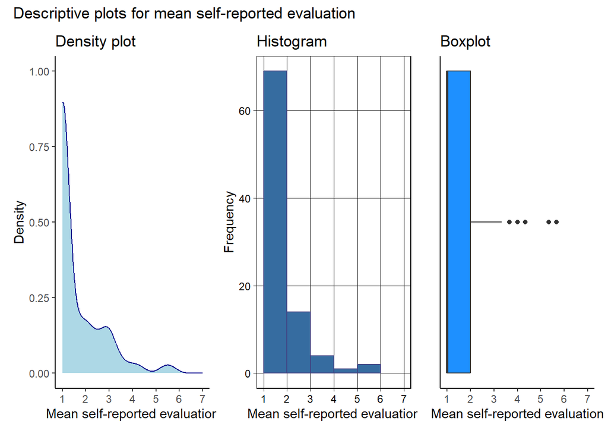

```r
# Histogram for mean self-reported evaluation
hist_sr <- ggplot(data_processed_after_exclusions, aes(x = mean_evaluation)) +
  geom_histogram(binwidth = 1,
                 boundary = 0,
                 fill = viridis_pal(begin = 0.45, option = "mako")(1),
                 color = viridis_pal(begin = 0.30, option = "mako")(1)) +
  xlab("Mean self-reported evaluation") +
  ylab("Frequency") +
  theme_linedraw() +
  scale_x_continuous(breaks = pretty_breaks(n = 7)) +
  ggtitle("Histogram") +
  coord_cartesian(xlim = c(1, 7)) +
  theme(panel.grid.minor = element_blank())

# density plot for mean self-reported evaluation
dens_sr <- ggplot(data_processed_after_exclusions, aes(x = mean_evaluation)) +
  geom_density(fill = "lightblue",
               color = "darkblue") +
  scale_x_continuous(breaks = pretty_breaks(n=7),
                     limits = c(1,7),
                     name = "Mean self-reported evaluation") +
  scale_y_continuous(limits = c(0,1),
                     name = "Density") +
  ggtitle("Density plot") +
  theme_classic()

box_sr <- ggplot(data_processed_after_exclusions, aes(x = mean_evaluation)) +
  geom_boxplot(width = 0.2, fill = "dodgerblue") +
  scale_y_continuous(breaks = NULL,
                     label = NULL,
                     name = "") +
  scale_x_continuous(limits = c(1,7),
                     breaks = pretty_breaks(n = 7),
                     name = "Mean self-reported evaluation") +
  ggtitle("Boxplot") +
  theme_classic()

dens_sr + hist_sr + box_sr + plot_annotation("Descriptive plots for mean self-reported evaluation")
```

## AMP evaluations

### Descriptive stats

add table of means, SDs, Ns

```r
# overall AMP evaluations
dat_mean_ratings_AMP <- data_processed_after_exclusions |>
  summarise(Mean = mean(AMP_score, na.rm = TRUE),
            SD = sd(AMP_score, na.rm = TRUE),
            n = n()) |>
  mutate(group = "Full sample")

# AMP evaluations by gender category
dat_mean_ratings_by_gender_AMP <- data_processed_after_exclusions |>
  group_by(group = gender) |>
  summarise(Mean = mean(AMP_score, na.rm = TRUE),
            SD = sd(AMP_score, na.rm = TRUE),
            n = n())

# combine both into one table
bind_rows(dat_mean_ratings_AMP,
          dat_mean_ratings_by_gender_AMP) |>
  select(Subset = group, Mean, SD, n) |> # select variables of interest, and rename one
  mutate(Subset = stringr::str_to_sentence(Subset)) |> # Change the case of the Subset variable so that it prints nicely
  mutate_if(is.numeric, round_half_up, digits = 2) |>
  kable() |>
  add_header_above(header = c(" " = 1, "AMP evaluations" = 3)) |>
  kable_classic(full_width = FALSE)
```

| Subset | AMP evaluations Mean | AMP evaluations SD | AMP evaluations n |
| --- | --- | --- | --- |
| Full sample | 0.58 | 0.19 | 90 |
| Female | 0.58 | 0.21 | 39 |
| Male | 0.58 | 0.18 | 48 |
| Nonbinary | 0.55 | 0.06 | 3 |

### Descriptive plots

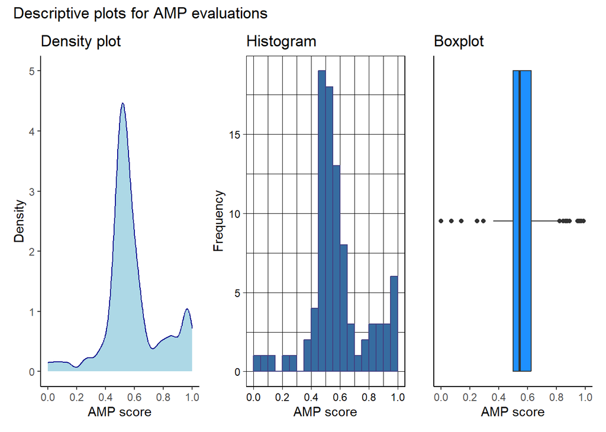

```r
#histogram for AMP score
hist_amp <- ggplot(data_processed_after_exclusions, aes(x = AMP_score)) +
  geom_histogram(binwidth = 0.05,
                 boundary = 0,
                 fill = viridis_pal(begin = 0.45, option = "mako")(1),
                 color = viridis_pal(begin = 0.30, option = "mako")(1)) +
  xlab("AMP score") +
  ylab("Frequency") +
  ggtitle("Histogram") +
  theme_linedraw() +
  scale_x_continuous(breaks = pretty_breaks(n = 4))

# density plot for AMP score
dens_amp <- ggplot(data_processed_after_exclusions, aes(x = AMP_score)) +
  geom_density(fill = "lightblue",
               color = "darkblue") +
  scale_x_continuous(breaks = pretty_breaks(n = 4),
                     limits = c(0,1),
                     name = "AMP score") +
  scale_y_continuous(limits = c(0,5),
                     name = "Density") +
  ggtitle("Density plot") +
  theme_classic()

box_amp <- ggplot(data_processed_after_exclusions, aes(x = AMP_score)) +
  geom_boxplot(width = 0.2, fill = "dodgerblue") +
  scale_y_continuous(breaks = NULL,
                     label = NULL,
                     name = "") +
  scale_x_continuous(limits = c(0,1),
                     breaks = pretty_breaks(n = 4),
                     name = "AMP score") +
  ggtitle("Boxplot") +
  theme_classic()

dens_amp + hist_amp + box_amp + plot_annotation("Descriptive plots for AMP evaluations")
```

# Analyses & hypothesis tests

## Self-reported evaluations are correlated with evaluations on the AMP

### Plot

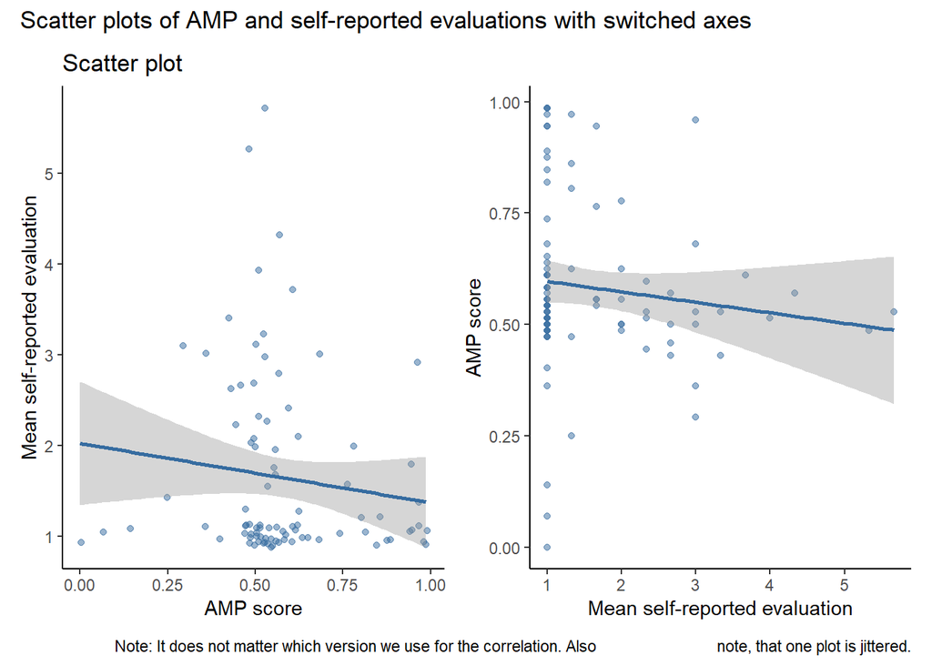

```r
#
jitter_plot <- ggplot(data_processed_after_exclusions,
       aes(x = AMP_score,
           y = mean_evaluation)) +
  geom_jitter(color = viridis_pal(begin = 0.45, option = "mako")(1),
              alpha = 0.5) +
  geom_smooth(method = "lm",
              color = viridis_pal(begin = 0.45, option = "mako")(1)) +
  xlab("AMP score") +
  ylab("Mean self-reported evaluation") +
  ggtitle("Scatter plot") +
  theme_classic()

point_plot <- ggplot(data_processed_after_exclusions,
       aes(y = AMP_score,
           x = mean_evaluation)) +
  geom_point(color = viridis_pal(begin = 0.45, option = "mako")(1),
              alpha = 0.5) +
  geom_smooth(method = "lm",
              color = viridis_pal(begin = 0.45, option = "mako")(1)) +
  ylab("AMP score") +
  xlab("Mean self-reported evaluation") +
  theme_classic()

jitter_plot + point_plot +
  plot_annotation(title = "Scatter plots of AMP and self-reported evaluations with switched axes",
                  caption = "Note: It does not matter which version we use for the correlation. Also                             note, that one plot is jittered.")
```

More complex plots:

#### Axial histograms

Scatter plots with axial histograms using ggExtra: https://cran.r-project.org/web/packages/ggExtra/vignettes/ggExtra.html

add axial histograms to a scatter plot. Split both the scatter plot and the histograms by gender.

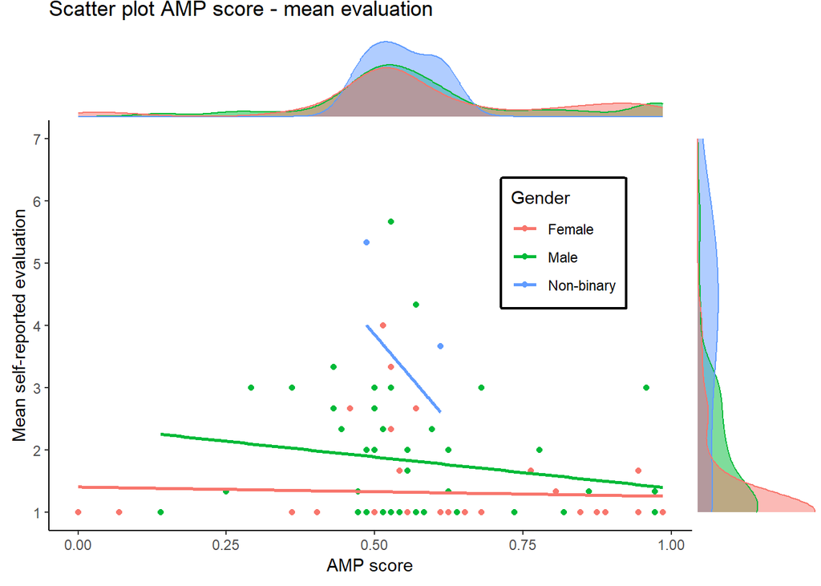

```r
axialHist <- ggplot(data_processed_after_exclusions,
             aes(x = AMP_score,
                 y = mean_evaluation, color = gender)) +
  geom_point() +
  geom_smooth(se = FALSE, method = "lm") +
  ggtitle("Scatter plot AMP score - mean evaluation") +
  xlab("AMP score") +
  scale_y_continuous(limits = c(1,7),
                     breaks = pretty_breaks(n = 7),
                     name = "Mean self-reported evaluation") +
  theme_classic() +
  theme(legend.position = c(0.8, 0.7),
        legend.box.background = element_rect(color = "black",
                                             linewidth = 1.5)) +
  scale_color_discrete(name = "Gender", labels = c("Female", "Male", "Non-binary"))


scatter_hist <- ggMarginal(axialHist, groupColour = TRUE, groupFill = TRUE)
scatter_hist
```

#### Labelled points

Label points using ggrepel: https://cran.r-project.org/web/packages/ggrepel/vignettes/ggrepel.html

Label the points in a scatter plot using their participant codes. Label only the participants with more extreme scores.

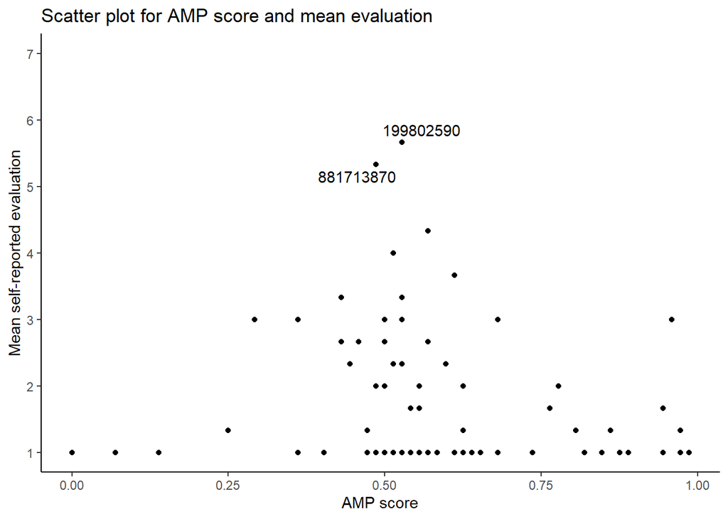

```r
scatter_repel <- data_processed_after_exclusions |>
  mutate(extreme = ifelse(mean_evaluation > 5, subject, "")) |>
  ggplot(aes(x = AMP_score,
             y = mean_evaluation,
             label = extreme)) +
  geom_point() +
  geom_text_repel() +
  ggtitle("Scatter plot for AMP score and mean evaluation") +
  xlab("AMP score") +
  scale_y_continuous(limits = c(1,7),
                     breaks = pretty_breaks(n = 7),
                     name = "Mean self-reported evaluation") +
  theme_classic()


scatter_repel
```

#### Magnify areas

Magnify areas of your plot with ggmagnify: https://hughjonesd.github.io/ggmagnify/

Magnify an area of one of your scatter plots, eg where there are a lot of data points in a small area.

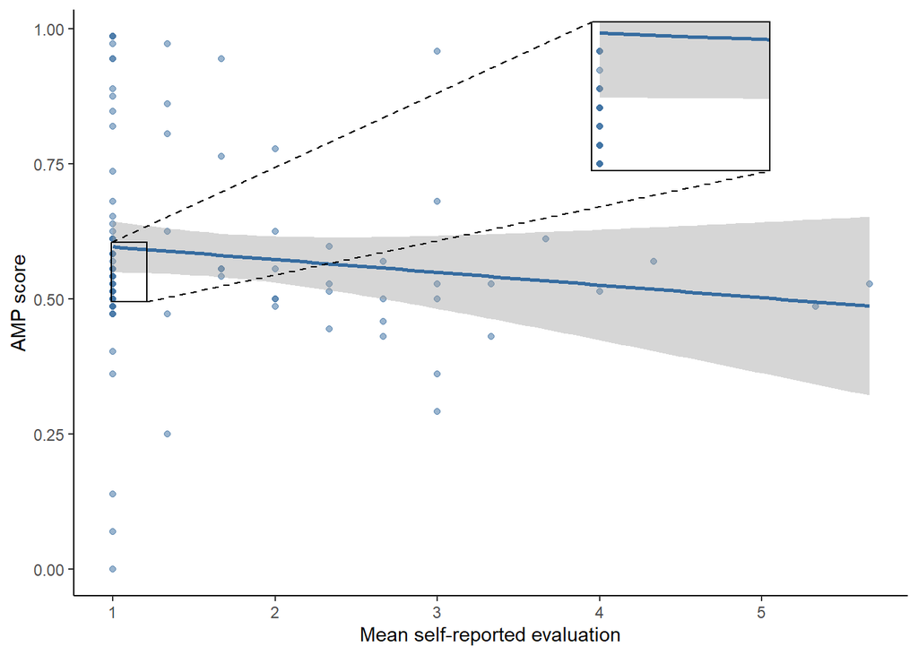

```r
from <- c(xmin = 1, xmax = 1.2, ymin = 0.5, ymax = 0.6)
to <- c(xmin = 4, xmax = 5, ymin = 0.75, ymax = 1)

point_plot + geom_magnify(from = from, to = to) +
  theme_classic()
```

### Test

run an appropriate test. Below the output, interpret the results: write a few sentences that report and interpret the results following APA reporting style.

```r
# Perform correlation analysis and report the result
data_processed_after_exclusions |>
  with(cor.test(mean_evaluation, AMP_score,
                alternative = "two.sided",
                method = "spearman",
                exact = FALSE))
```

```
##
##  Spearman's rank correlation rho
##
## data:  mean_evaluation and AMP_score
## S = 136965, p-value = 0.2314
## alternative hypothesis: true rho is not equal to 0
## sample estimates:
##        rho
## -0.1274223
```

**Result:** Spearman’s rank correlation was used to assess the relationship between mean self-reported evaluation and AMP score. This two-sided test was non-significant r(88) = -0.13, p = 0.231. Thus, the test indicates a negative, but non-significant relationship between the two variables.

## Self-reported evalautions differ between men and women

### Plot

split histogram, split violin plot, raincloud plot, etc.

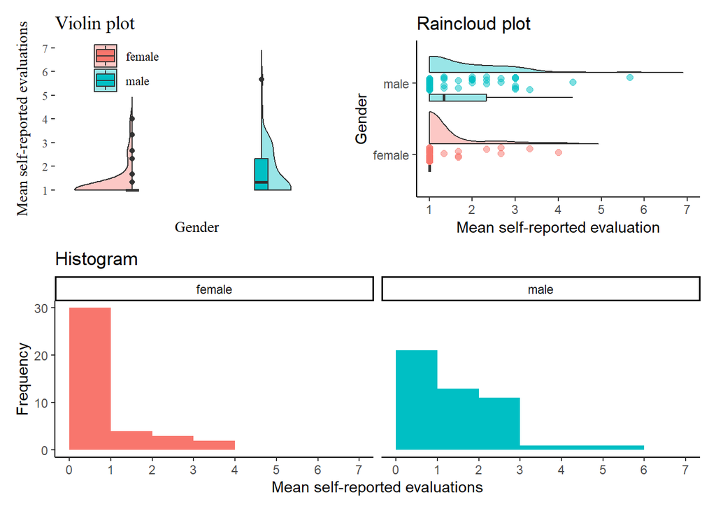

```r
# Constants and subset
rain_height <- .1

male_female_subset <- data_processed_after_exclusions |>
  filter(gender %in% c("male", "female"))


# Split histogram
sr_gender_hist <- male_female_subset |>
  ggplot(aes(x = mean_evaluation, fill = gender)) +
  geom_histogram(binwidth = 1,
                 boundary = 0) +
  xlab("Mean self-reported evaluations") +
  ylab("Frequency") +
  ggtitle("Histogram") +
  scale_x_continuous(breaks = pretty_breaks(n = 7),
                     limits = c(0, 7)) +
  facet_wrap(~gender) +
  theme_classic() +
  theme(legend.position = "none")


# Split violin plot
sr_gender_violin <- male_female_subset |>
  ggplot(aes(x = gender, y = mean_evaluation, fill = gender)) +
  introdataviz::geom_split_violin(alpha = .4, trim = FALSE,
                                  na.rm=TRUE) +
  geom_boxplot(width = 0.1) +
  xlab("Gender") +
  ylab("Mean self-reported evaluations") +
  ggtitle("Violin plot") +
  scale_y_continuous(breaks = pretty_breaks(n = 7),
                     limits = c(1, 7)) +
  scale_x_discrete(breaks = "",
                   labels = "") +
  theme_tufte() +
  theme(legend.position = c(.25,.85),
        legend.title = element_blank())


# Split raincloud plot
sr_gender_raincloud <- ggplot(male_female_subset, aes(x = gender, y = mean_evaluation, fill = gender)) +
  introdataviz::geom_flat_violin(trim=FALSE, alpha = 0.4,
                                 position = position_nudge(x = rain_height+.05),
                                 na.rm=TRUE) +
  geom_point(aes(colour = gender), size = 2, alpha = .5, show.legend = FALSE,
             position = position_jitter(width = rain_height, height = 0)) +
  geom_boxplot(width = rain_height, alpha = 0.4, show.legend = FALSE,
               outlier.shape = NA, position = position_nudge(x = -rain_height*2)) +
  ggtitle("Raincloud plot") +
  scale_y_continuous(breaks = pretty_breaks(n = 7),
                     limits = c(1,7),
                     name = "Mean self-reported evaluation") +
  scale_x_discrete(name = "Gender") +
  coord_flip() +
  theme_classic() +
  theme(legend.position = "none")

(sr_gender_violin | sr_gender_raincloud)/sr_gender_hist
```

### Test

run an appropriate test. Below the output, interpret the results: write a few sentences that report and interpret the results following APA reporting style.

```r
result_nonpar <- wilcox.test(mean_evaluation ~ gender, data = male_female_subset,
                             alternative = "two.sided", exact = FALSE)
result_nonpar
```

```
##
##  Wilcoxon rank sum test with continuity correction
##
## data:  mean_evaluation by gender
## W = 622.5, p-value = 0.002773
## alternative hypothesis: true location shift is not equal to 0
```

**Results:** A Wilcoxon rank sum test (or Mann-Whitney U test) with continuity correction was performed to compare mean self-reported evaluation between men and women. Two-sided testing revealed a significant result (W = 622.5, p = 0.003), thus indicating that the two groups differ in their central tendency. More specifically, women’s explicit self-reported evaluations were lower on average than men’s.

### Plot

split histogram, split violin plot, raincloud plot, etc.

This time, vary the labeling and order of the legend, e.g., capitalise “Men” and “Women”, and know how to change the order of the factors.

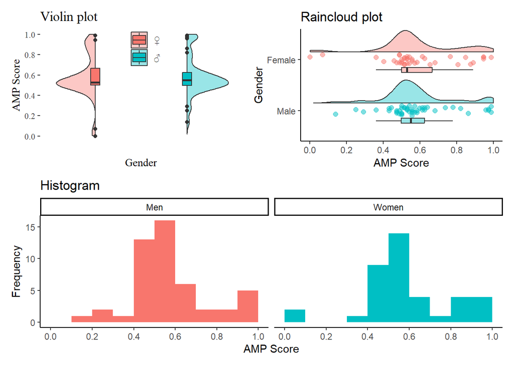

```r
# Constants and subset
rain_height <- .1

male_female_subset <- data_processed_after_exclusions |>
  filter(gender %in% c("male", "female"))


# Split histogram
amp_gender_hist <- male_female_subset |>
  mutate(gender = recode(gender, "male" = "Men", "female" = "Women")) |>
  ggplot(aes(x = AMP_score, fill = gender)) +
  geom_histogram(binwidth = 0.1,
                 boundary = 0) +
  xlab("AMP Score") +
  ylab("Frequency") +
  ggtitle("Histogram") +
  scale_x_continuous(breaks = pretty_breaks(n = 5),
                     limits = c(0, 1)) +
  facet_wrap(~gender) +
  theme_classic() +
  theme(legend.position = "none")


# Split violin plot
amp_gender_violin <- male_female_subset |>
  mutate(gender = recode(gender, "female" = "♀", "male" = "♂")) |>
  ggplot(aes(x = gender, y = AMP_score, fill = gender)) +
  introdataviz::geom_split_violin(alpha = .4, trim = FALSE,
                                  na.rm=TRUE) +
  geom_boxplot(width = 0.1) +
  xlab("Gender") +
  ylab("AMP Score") +
  ggtitle("Violin plot") +
  scale_y_continuous(breaks = pretty_breaks(n = 5),
                     limits = c(0, 1)) +
  scale_x_discrete(breaks = "",
                   labels = "") +
  theme_tufte() +
  theme(legend.position = c(.52,.85),
        legend.title = element_blank())


# Split raincloud plot
amp_gender_raincloud <- ggplot(male_female_subset, aes(x = gender, y = AMP_score, fill = gender)) +
  introdataviz::geom_flat_violin(trim=FALSE, alpha = 0.4,
                                 position = position_nudge(x = rain_height+.05),
                                 na.rm=TRUE) +
  geom_point(aes(colour = gender), size = 2, alpha = .5, show.legend = FALSE,
             position = position_jitter(width = rain_height, height = 0)) +
  geom_boxplot(width = rain_height, alpha = 0.4, show.legend = FALSE,
               outlier.shape = NA, position = position_nudge(x = -rain_height*2)) +
  ggtitle("Raincloud plot") +
  scale_y_continuous(breaks = pretty_breaks(n = 5),
                     limits = c(0,1),
                     name = "AMP Score") +
  scale_x_discrete(name = "Gender",
                   limits = c("male", "female"),
                   labels = c("Male", "Female")) +
  coord_flip() +
  theme_classic() +
  theme(legend.position = "none")

(amp_gender_violin | amp_gender_raincloud)/amp_gender_hist
```

### Test

run an appropriate test. Below the output, print an interpretation of the results generated by the ‘easystats’ package [report](https://easystats.github.io/report/). I.e., use `report::report()`.

```r
result_amp <- t.test(mean_evaluation ~ gender, data = male_female_subset, var.equal = FALSE)
result_amp
```

```
##
##  Welch Two Sample t-test
##
## data:  mean_evaluation by gender
## t = -2.616, df = 83.137, p-value = 0.01056
## alternative hypothesis: true difference in means between group female and group male is not equal to 0
## 95 percent confidence interval:
##  -0.8613407 -0.1172918
## sample estimates:
## mean in group female   mean in group male
##             1.316239             1.805556
```

```r
report(result_amp)
```

```
## Effect sizes were labelled following Cohen's (1988) recommendations.
##
## The Welch Two Sample t-test testing the difference of mean_evaluation by gender
## (mean in group female = 1.32, mean in group male = 1.81) suggests that the
## effect is negative, statistically significant, and medium (difference = -0.49,
## 95% CI [-0.86, -0.12], t(83.14) = -2.62, p = 0.011; Cohen's d = -0.57, 95% CI
## [-1.01, -0.13])
```

## Combining plots

Combine plots using patchwork: https://patchwork.data-imaginist.com/

Combine at least three of the above plots into one.

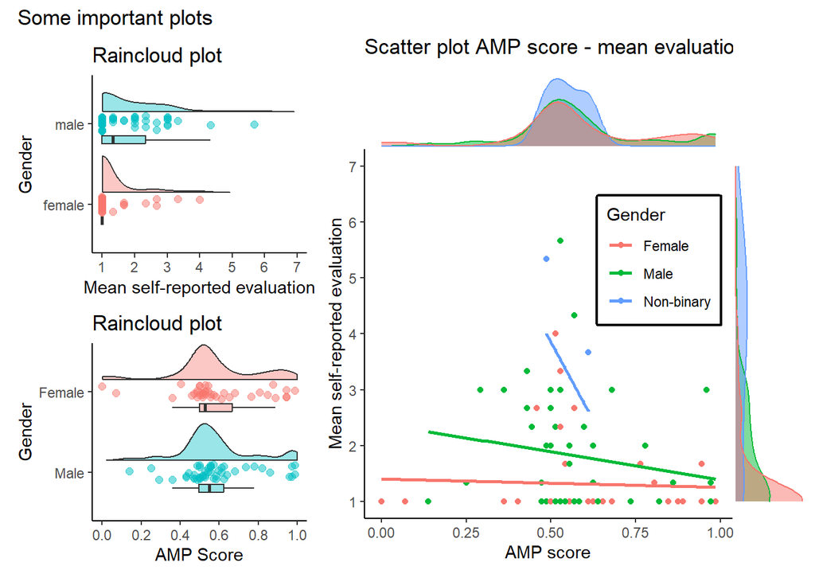

```r
all_plots <- sr_gender_raincloud / amp_gender_raincloud - scatter_hist +
  plot_layout(widths = c(1, 2.2)) +
  plot_annotation(title = "Some important plots")

all_plots
```

## Saving plots

Save plots to disk with `ggsave()`

Save the above combined plot to disk as both .png and .pdf. Ensure the png has at least 300dpi resolution.

```r
dir.create("../plots")

ggsave("evaluation_amp_plots.png",
       plot = all_plots,
       width = 10,
       dpi = 300,
       path = "../plots")

ggsave("evaluation_amp_plots.pdf",
       plot = all_plots,
       width = 10,
       path = "../plots")
```